# MetodeOptimizacije

Benchmark gradijentnih algoritama za minimizaciju cost functiona u neuronskim mrežama.

Kolegij: Metode optimizacije

## Uvod u neuronske mreže

Model neuronske mreže počiva na stvarnom modelu neurona:

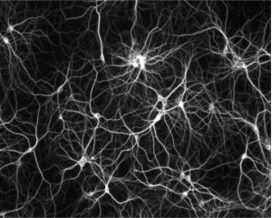

Svaki neuron može se podijeliti u 3 ključna dijela:

1. Ulazni impuls,
2. Obrada impulsa - aktivacijska funkcija,
3. Izlazni impuls,

odnosno

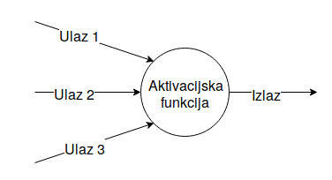

a spajanjem neurona nastaje neuronska mreža koja ima nekoliko slojeva od kojih svaki sloj ima proizvoljno veliki broj neurona:

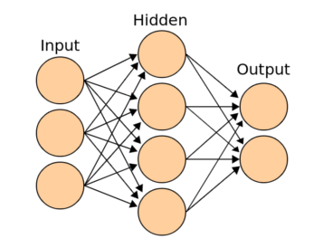

Ulazni impuls može biti bilo koja **značajka** koja se može kvantizirati. Ako je ulazni impuls slika, tada je svaki od ulaza vrijednost jednog njegovog pixela. Konkretnije: ako postoji RGB slika dimenzija $(600 \times 600 \times 3 )$ koju postavljamo na ulaz neuronske mreže, tada na ulazu dobivamo $(600 \cdot 600 \cdot 3 = 1,080,000)$ impulsa.

Obrada impulsa kaže koliko će ulazni signal biti jači/slabiji na izlazu, odnosno kako ćemo kombinirati ulazne impulse. Budući da se ulazni impulsi na neki način aktiviraju i tvore izlazni impuls, ovaj korak se naziva **Aktivacijska funkcija** (reprezentira se pomoću matematičkih funkcija) ( [Aktivacijske funkcije](https://towardsdatascience.com/activation-functions-neural-networks-1cbd9f8d91d6)). Neke od najčešćih aktivacijskih funkcija su:

1. *Sigmoid ili Logistic Activation Function*
2. *Tanh ili hyperbolic tangent Activation Function*
3. *ReLU - Rectified linear unit**
4. *Razne egzotične aktivacijske funkcije*

Te na posljetku postoji **izlazni impuls** koji se propagira dalje kroz neuronsku mrežu. Izlazni impuls neuralne mreže se potom može tumačiti na različite načine: kao vrijednost neke složene funkcije, pripadnost nekoj klasi, predviđanje regresije... Tumačenje izlaza striktno je vezano uz topologiju i vrstu neuronske mreže.

## Treniranje neuronske mreže: odabir topologije i propagacija prema naprijed

Kao primjer treniranja neuronske mreže uzeti ćemo jednostavni set podataka koji je prethodno normaliziran i na njemu želimo vršiti binarnu klasifikaciju prolaznika testa u ovisnosti o ostvarenim bodovima na usmenom i pismenom dijelu testa ($x_1$ i $x_2$).

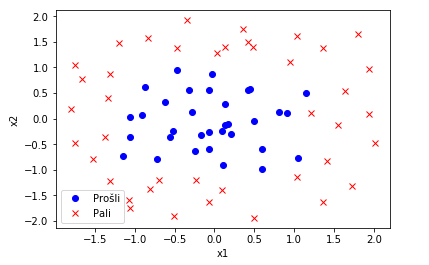

Nakon pripreme seta podataka, potrebno je definirati i odlučiti topologiju neuronske mreže. Najčešća nit vodilja u odabiru topologije neuronske mreže jest pronalazak sličnog problema koji je već riješen pomoću neuronske mreže te iskoristiti tu istu topologiju za naš problem. Ako ne postoji sličan problem, tada se može uzeti neka "state-of-the-art" topologija poput: VGG, ResNet, Inception...(više na [poveznici](https://www.pyimagesearch.com/2017/03/20/imagenet-vggnet-resnet-inception-xception-keras/)).

Za prethodno navedeni primjer nije potrebno koristiti složenu topologiju budući da iz same razdiobe podataka možemo uočiti da je granica razdvajanja dviju klasa podjsća na kružnicu:

$$x^2 + y^2 = r^2$$

U obliku funkcije: $$f(x,y,r) = x^2 + y^2 - r ^ 2$$

Za dane podatke moramo na svaki od parametara dodati još težinu kojom taj parametar utječe na sam izgled funkcije:

$$f(x_1,x_2,r) = x_1^2\cdot\theta_1 + x_2^2\cdot\theta_2 - r^2\cdot\theta_0$$

Funkcija kružnice može se modlirati pomoću komputacijskog grafa koji zapravo reprezentira jednostavnu neuronsku mrežu: (radi kraćeg zapisa od sada ćemo funkciju $f(x_1,x_2,r)$ oslovljavati sa $z$)

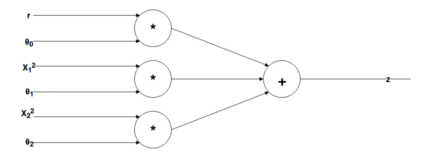

Vektorski zapis ove funkcije glasi:

$ulaz = \begin{bmatrix} r& x_1^2 & x_2^2 \end{bmatrix}$ $\Theta = \begin{bmatrix} \theta_0 \\ \theta_1 \\ \theta_2 \end{bmatrix}$

$ z = ulaz \cdot \Theta$

Propagacija prema naprijed izračun je izlaza neuronske mreže za određeni ulaz. Na primjer za sljedeće vrijednosti parametara: $x_1 = 0.6, x_2 = 0.7, y=1$, $r=1$, $\theta_0 = -0.5, \theta_1 = 0.5, \theta_2 = 0.3$ (podaci su normalizirani) naša jednostavna neuronska mreža ima izlaz:

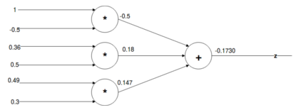

Naposljetku valja protumačiti vrijednost funkcije $z$. Ako su klase "Prošao " i "Pao" označene s $1$, a "Pao" označena s $0$. Rezultat $z = -0.1730$ nam ne govori kojoj klasi pripada prolaznik sa ostvarenim rezultatom $x_1=0.6, x_2=0.7$ na testu. U tu svrhu i kako bi se dodala **nelinearnost** modelu, dodaje se aktivacijska funkciju. Klasični primjer je sigmoidna aktivacijska funkcija pa će se i u ovom slučaju ona dodati:

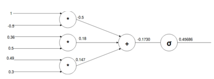

Rezultat sigmoida iznosi $\sigma = \hat y = 0.45686$. Uz granicu odluke od $0.5$ koja je uobičajena, model bi predvidio oznaku $0$ ("Pao") $(\hat y = 0.45686 \leq 0.5)$. Naravno cilj je da model predvidi $\hat y = 0$ ili neki broj vrlo blizak $0$ ukoliko je $0$ ispravna klasa. U tu svrhu moramo popraviti parametre $\Theta$.

## Treniranje neuronske mreže: Funkcija cilja $J(\theta)$ i propagacija prema natrag

Propagacija prema natrag dolazi od kretanja kroz neuronsku mrežu (komputacijski dijagram) unatrag. Propagacija prema naprijed rezultirala je izlazu neuronske mreže za dani ulaz, dok propagacija unatrag služi podešavanju parametara $\Theta$ kako bi predviđeni rezultat neuronske mreže bio čim bliži stvarnome (stvarnoj klasi ulaznih podataka). Kako bi se mogla validirati uspješnost predviđana rezultata/klase neuronske mreže uvodi se funkcija cilja $J(\Theta)$ koja mjeri performansu neuronske mreže. Drugim riječima putem funkcije cilja traže se optimalne vrijednosti parametra $\Theta$. Jedna od najčešćih funkcija cilja kod plitkih neuronskih mreža, kao što je prethodni primjer. jest funkcija **srednje kvadratne pogreške (MSE)**:

$$ MSE = J(\Theta) = \frac{\sum_{i = 0}^{m}(y_i - \hat{y}_i)^2}{2m} $$

U grafu neuronske mreže funkcija cijene se nikad ne prikazuje budući da ona ne postoji prilikom korištenja modela, već samo dok se model trenira. U svrhu treniranja i radi lakšeg shvaćanja postupka propagacije prema natrag ovdje ćemo ju prikazati i odmah izračunati za dani primjer:

$$ error = \frac{(0-0.45686)^2}{2} = 0.10436 $$

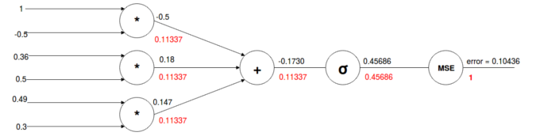

Idući korak jest propagacija $error$-a prema svakom parametru $\Theta$. Kako bi se $error$ propagirao koristi se algoritam **gradijentni spust**. Kreće se od izlaza neuronske mreže prema početku stoga se računa gradijent pri samom kraju, odnosno kakav je gradijent funkcije cilja po funkciji cilja, a on iznosi:

$$\frac{\delta J(\theta)}{\delta J(\theta)} = \frac {\delta MSE}{\delta MSE}= 1$$

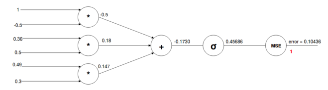

Sljedeći korak jest izračun kako ulaz u funkciju $MSE$ utječe na $error$, odnosno izračun gradijenta pri funkciji $MSE$:

$$\frac{\delta MSE}{\delta \hat y} = \frac{\delta \frac{(y - \hat{y})^2}{2}}{\delta \hat y} = (y - \hat y) \cdot (-1) = 0.45686$$

Ovu pogrešku moramo još multiplicirati za pogrešku pri funkciji cilja koja iznosi $1$:

$$\frac{\delta J(\theta)}{\delta J(\theta)} \cdot \frac{\delta MSE}{\delta \hat y} = 0.45686 $$

Primjenjeno pravilo jest pravilo **ulančanog deriviranja** na koje se zapravo i svodi čitav algoritam propagacije prema natrag ([Ulančano deriviranje](https://en.wikipedia.org/wiki/Chain_rule)).

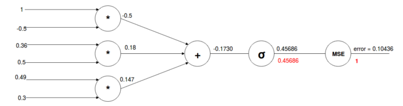

Sljedeći korak je izračun gradijenta pri sigmoid funkciji. Ulaz u sigmoid funkciju jest $z$:

$$ \frac{\delta \sigma}{\delta z} = (\sigma) * (1-\sigma) = (0.45686)*(1-0.45686) = 0.24814$$

Još treba multiplicirati sa gradijentom prethodnog koraka: $$ 0.45686 * 0.24814 = 0.11337$$

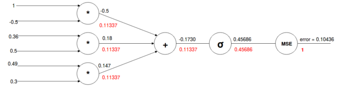

Funkcija zbrajanja prosljeđuje gradijent na sve članove koji se zbrajaju. Raspisane derivacije funkcije $z$ glase: "$r\cdot \theta_0$", "$x_1^2\cdot\theta_1$" i "$x_2^2 \cdot \theta_2$". Funkcija $z$ glasi: $z = r\cdot \theta_0 + x_1^2\cdot\theta_1 + x_2^2 \cdot \theta_2$. Derivacija funkcije $z$ po bilo kojem od ulaza iznosi $1$. Zbog ulančanog deriviranja još treba pomnožiti s gradijentnom u prethodnom koraku, a to je $0.11337$.

Sada preostaje propagirati gradijent do $\theta$. Izračun gradijenata za svaki od $\Theta$ glasi:

$$\frac{\delta \theta_0 \cdot r}{\delta \theta_0} \cdot 0.11337 = r \cdot 0.11337 = 1 \cdot 0.11337 = 0.11337$$$$\frac{\delta \theta_1 \cdot x_1^2}{\delta \theta_1} \cdot 0.11337 = x_1^2 \cdot 0.11337 = 0.36 \cdot 0.11337 = 0.040813$$$$\frac{\delta \theta_2 \cdot x_2^2}{\delta \theta_2} \cdot 0.11337 = x_2^2 \cdot 0.11337 = 0.49 \cdot 0.11337 = 0.055551$$

Dakle izračunati gradient za parametar $\Theta$ glasi:

$$\Theta' = \begin{bmatrix}0.11337 \\0.040813 \\ 0.055551 \end{bmatrix}$$

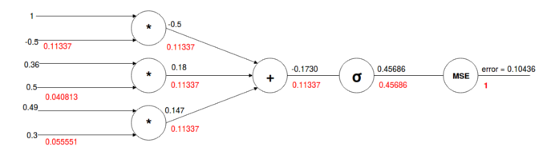

Ažuriranje gradijenta vrši se po formuli: $$\Theta = \Theta - \frac{\alpha}{m} \cdot \Theta'$$

Uz pretpostavljenu stopu učenja $\alpha = 0.03$, novi $\Theta$ iznosi:

$$\Theta = \begin{bmatrix}-0.5 \\ 0.5 \\ 0.3\end{bmatrix} - \frac{0.03}{1} \cdot \begin{bmatrix}0.11337 \\0.040813 \\ 0.055551\end{bmatrix} = \begin{bmatrix} -0.50340 \\ 0.49878\\ 0.29833\end{bmatrix} $$

#### Provjera rezultata gradijentnog spusta

Ako se novi $\Theta$ primjeni na danom primjeru, trebao bi polučiti bolji rezultat:

$$\hat y = \sigma(1\cdot(-0.50340) + 0.36 \cdot 0.49878 + 0.49 \cdot0.29833) = \sigma(-0.17766) = 0.45570 $$

Novo dobiveni $\hat y$ iznosi $0.45570$ što je bliže očekivanoj klasi $0$ nego $0.45686$. Ovime se dokazuje da je novi izračunati $\Theta$ bolji od prethodnog. **Propagacija prema natrag** završava ovim korakom, odnosno u daljnjem treniranju ponavljale bi se iteracije propagacije prema naprijed i propagacije prema natrag.

## Treniranje neuronske mreže: Zaustavljanje treniranja i Cross-validacija

Prilikom zaustavljanja treniranja neuronske mreže koriste sve dva ustaljena mehanizma:

1. Broj iteracija,
2. Zaustavljanje pomoću "elbow" metode na cross-validacijskom setu podataka.

### Broj iteracija

Vrlo jednostavno princip zaustavljanja treniranja neuronske mreže jest prekid treniranja nakon određenog broja iteracija. Problem leži u činjenici da ukoliko treniramo neuronsku mrežu veliki broj iteracija, tada će se parametri previše prilagoditi trening setu podataka, što znači da postoji šansa da neuronska mreža loše generalizira na test setu podataka. Druga krajnost jest da treniramo neuronsku mrežu za premali broj iteracija. U ovom slučaju neuronska mreža jednostavno neće stići naučiti optimalne parametre što znači da će polučiti loše rezultate.

### Zaustavljanje pomoću Cross-validacije

Kako bi pronašli optimalni broj iteracija/epoha treniranja neuronske mreže, koristi se metoda Cross-validacije odnosno koristi se Cross-validacijski set. Cross-validacijski set dobiva se tako da se od trening seta uzme uobičajeno $20\%$ podataka koji će "glumiti" test set tijekom treniranja. Dakle na preostalih $80\%$ trening seta trenira se neuronska mreža, dok se nakon svake iteracije evaluira na cross-validacijskom setu. Pogreška treniranja na trening setu će se konstantno smanjivati, dok će se na cross-validacijskom setu smanjivati do određene točke, a potom će se zbog pretjerane prilagodbe modela na trening set podatke početi povećavati čineći tako svojevrsni "lakat" (*engl. elbow*). U tom trenutku prekidamo treniranje neuronske mreže.

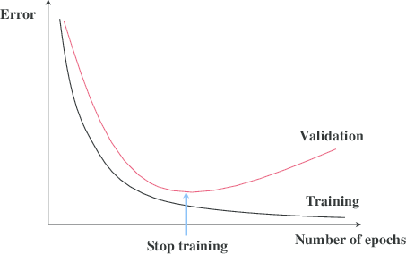